# A Watched Pot Boiling

Street Protest and Public Opinion in Authoritarian Russia

Noah Buckley

Trinity College Dublin

July 4, 2024

## Protest in authoritarian regimes

- Autocrats’ fear of popular protest is central to many theories of authoritarian survival (Simpser 2013; Svolik 2012)
- Informational and reputational cascade (Kuran 1991; Lohmann 1994)
  - Protest can lead to a spiral of yet more protest
- Monitoring of protest and sentiment
  - Informational autocracy (Guriev and Treisman 2020)
  - Autocrats put considerable effort into public opinion polls

## What we know and what we don’t

- Social desirability rather than fear of repression is behind much preference falsification (Buckley, Marquardt, Reuter, and Tertytchnaya 2024)
- Protest works differently for different groups: state employees (Rosenfeld 2017), media consumption and regime response (Lankina and Tertytchnaya 2019; Wasow 2020)
- Focus has been on the **social environment** and unexpected permission to protest (Frye and Borisova 2019)
- What about the **content of informational shocks** and their effects?
  - Real-world informational shocks can contain multiple ‘messages’ about society and regime
  - How do these diverse types of messages pull different levers?

## Research questions

1. Does exposure to public protest shift **support** for a ruling authoritarian regime?
2. What are the **mechanisms** connecting exposure to protest and shifts in attitudes?

## Theoretical framework: protest as informational shock

**Observing public protest is an informational shock**

- **[RQ1]**{.label} Potential effects on individuals:
  - Dislike of local regime **agents**
  - Disaffection with larger system, regime, **autocrat**
  - Willingness to take action yourself
- **[RQ2]**{.label} Content of informational shocks:
  1. Revelation about levels of social discontent
  2. Likelihood of repression by the regime
  3. Revelation about regime quality

## Empirical strategy

- Very large database of public opinion data from Russia
  - Over 3.2 million responses, 2003–present
  - Interview date, subnational/geographical unit
- Scraped and coded data on protest events in Russia, 2007–2022
- Difference-in-differences approach to test hypotheses
- Individual-level survey data
- Treatment at the level of region
  - Proxy for observing protest
  - Future work: at the municipal level
- Rely on **precise timing of protest events** to identify this effect

## Protest data

[figure not shown]

- Protest events web-scraped from namarsh.ru
  - Volunteer-run collective; cooperative effort of 3 opposition NGOs
  - The most complete and authoritative source on protest in Russia
  - Covers March 2007 to 2022
- Coded protest characteristics
  1. Who is protesting
  2. What are the demands, content
  3. Number of protesters; detentions; approved by authorities
  4. Location

## Examples

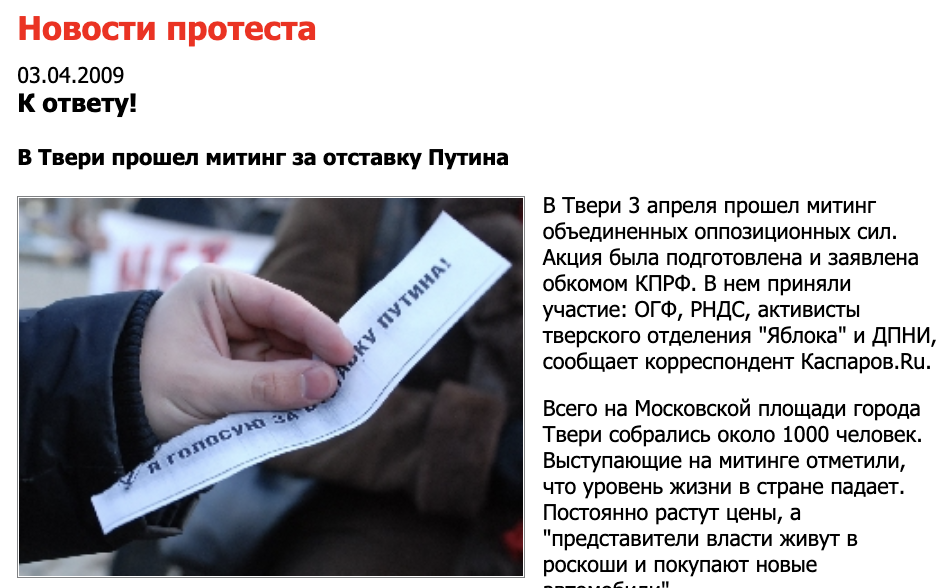

> *“A demonstration calling for Putin’s resignation took place in Tver”* — 03.04.2009.

> *On April 3, a demonstration of the united opposition took place. The event was prepared and announced by the KPRF. … In total, around 1000 people assembled… Attendees noted that the quality of life in the country is falling. Prices are rising while the authorities live in luxury…*

[figure not shown]

> *“Over 130 people across Russia detained at Navalny canvassing events”* — 09.07.2017.

> *…according to OVD-Info, participants faced detentions, searches, or attacks on July 8 in 18 cities: …*

## Protest descriptives

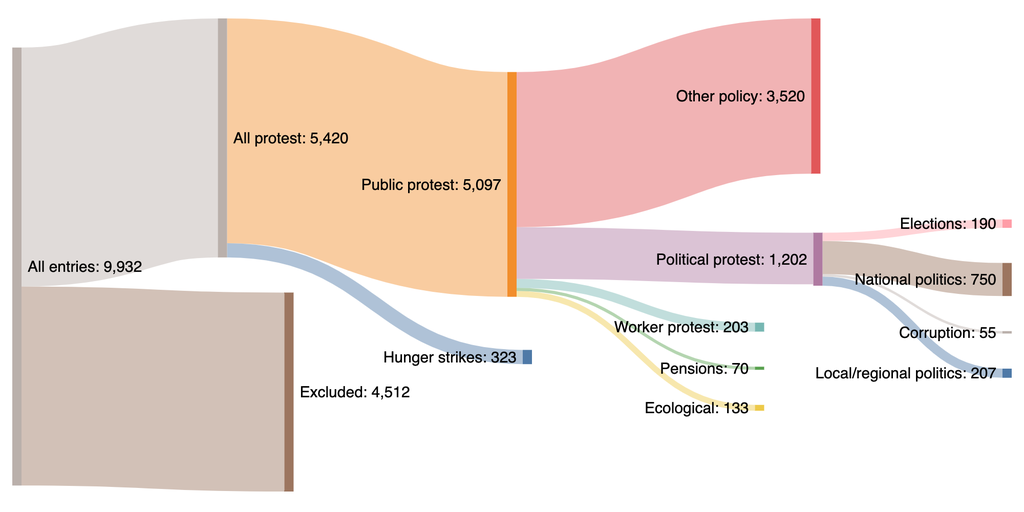

## Survey data

- Daily/monthly Russian public opinion survey data covering 13 years, 2007–2019
- 82 subnational units
- Unbalanced repeated cross-section of units
- Large, nationally/regionally-representative public opinion surveys
  - Levada Courier
  - VTsIOM Express
  - FOMnibus
- $N_\text{survey} = 655{,}059$
  - Omit rural respondents and Moscow, $N_\text{survey} = 334{,}494$

## Estimation strategy

**Staggered difference-in-differences**

- Linear probability model — OLS with TWFE
- Fixed effects: **region and month**; survey firm; locality size
- SEs clustered at region-week level

**Dependent variables** (dichotomous)

1. Approval of Putin
2. Approval of governor
3. *“If mass protests take place, will you participate in them?”*

**Predictors**

- **Predictor of interest:** binary indicator of protest in the region in last 14 days with 14 day exclusion period
- Additional predictors: age, education, gender

## Staggered difference-in-differences

- Potential for bias when conducting TWFE estimation of DiD with staggered treatment or heterogeneous treatment effects
  - See: de Chaisemartin and D’Haultfoeuille 2020; Goodman-Bacon 2021; Callaway and Sant’Anna 2021; Sun and Abraham 2021; Wooldridge 2021
- Proposed solutions assume:
  1. Non-nested, unit-level TSCS data structure
  2. Treatment is irreversible
  3. Treated units can be organized into well-defined cohorts
- This project:
  1. Individuals nested within region-months; heterogeneity across individuals
  2. Treatment is a shock with — presumably — temporary effects of unknown longevity
  3. Treatment is in continuous time, no natural cohorts

## Results: Protest and Putin approval

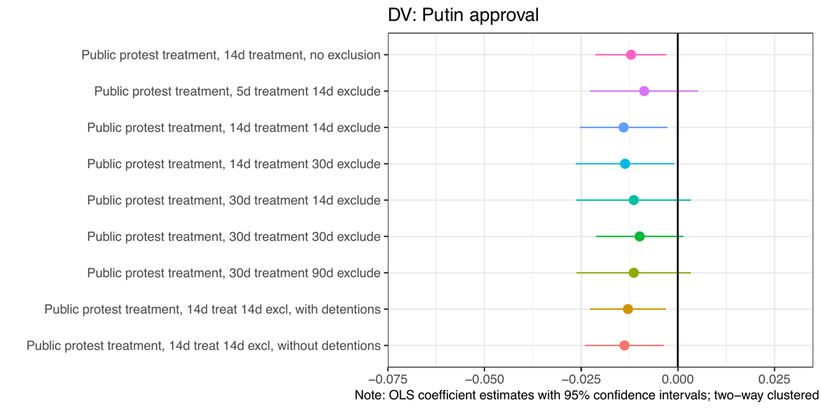

## Results: Protest and Putin approval

*DV: Putin approval. SEs clustered at region-week.*

|  | (1) | (2) | (3) | (4) |
| --- | --- | --- | --- | --- |
| Protest, 14d, no excl. | **−0.012*** |  |  |  |
|  | (0.005) |  |  |  |
| Protest, 14d / 14d excl. |  | **−0.014*** |  |  |
|  |  | (0.006) |  |  |
| Protest, 30d / 30d excl. |  |  | −0.010<sup>+</sup> |  |
|  |  |  | (0.006) |  |
| Protest, 14d / 14d, w/ detentions |  |  |  | **−0.013*** |
|  |  |  |  | (0.005) |
| Age | 0.000<sup>+</sup> | 0.000 | 0.000 | 0.000<sup>+</sup> |
|  | (0.000) | (0.000) | (0.000) | (0.000) |
| Education | −0.003 | −0.003<sup>+</sup> | −0.002 | −0.003 |
|  | (0.002) | (0.002) | (0.002) | (0.002) |
| Male | **−0.067***** | **−0.066***** | **−0.066***** | **−0.067***** |
|  | (0.005) | (0.005) | (0.005) | (0.005) |
| Fixed effects (4) | ✓ | ✓ | ✓ | ✓ |
| $N$ | 270,068 | 247,002 | 240,029 | 270,068 |
| $R^2$ | 0.067 | 0.067 | 0.067 | 0.066 |

<sup>+</sup> p<0.1, * p<0.05, ** p<0.01, *** p<0.001

## Results: Protest and willingness to take to the street

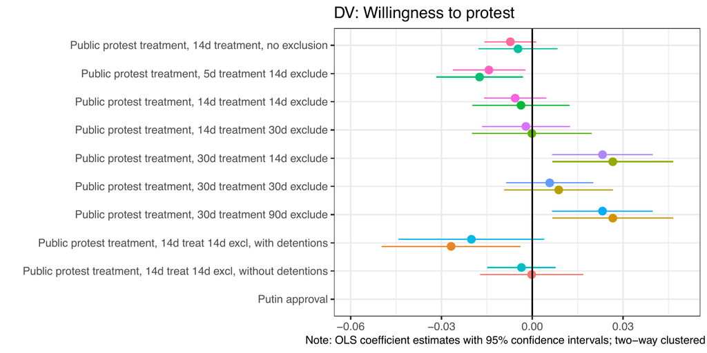

## Mechanisms: The content of the informational shock

1. Revelation about levels of social discontent
   - Protest gives permission to stop falsifying (Buckley, Marquardt, Reuter, and Tertytchnaya 2024)
   - $\Rightarrow$ Acknowledge dislike of **regime/autocrat**
2. Update of priors on probability of repression by the regime
   - Newfound ‘freedom’ to challenge the regime (Frye and Borisova 2019)
   - $\Rightarrow$ Increased **willingness to protest**
3. Learning about regime quality
   - Disillusionment, especially among regime supporters
   - $\Rightarrow$ Decreased approval for regime or agents, will depend on **protest demands**

## Results: Repression mechanism

*14-day treatment, 14-day exclusion. SEs clustered at region-week.*

|  | Would prt | Putin appr | Putin appr | Would prt | Would prt |
| --- | --- | --- | --- | --- | --- |
| Protest, no detentions |  |  | **−0.014**** |  | −0.004 |
|  |  |  | (0.005) |  | (0.006) |
| Protest, with detentions |  | **−0.013*** |  | −0.020<sup>+</sup> |  |
|  |  | (0.005) |  | (0.012) |  |
| Protest, any | −0.006 |  |  |  |  |
|  | (0.005) |  |  |  |  |
| Age | **−0.001***** | 0.000<sup>+</sup> | 0.000 | **−0.001***** | **−0.001***** |
|  | (0.000) | (0.000) | (0.000) | (0.000) | (0.000) |
| Education | **−0.006**** | −0.003 | −0.003 | **−0.006**** | **−0.006**** |
|  | (0.002) | (0.002) | (0.002) | (0.002) | (0.002) |
| Male | **0.038***** | **−0.067***** | **−0.066***** | **0.038***** | **0.038***** |
|  | (0.004) | (0.005) | (0.005) | (0.003) | (0.004) |
| Fixed effects (4) | ✓ | ✓ | ✓ | ✓ | ✓ |
| $N$ | 173,759 | 270,068 | 247,697 | 192,494 | 174,073 |
| $R^2$ | 0.039 | 0.066 | 0.067 | 0.038 | 0.039 |

<sup>+</sup> p<0.1, * p<0.05, ** p<0.01, *** p<0.001

## Results: Regime quality mechanism

*14-day treatment, 14-day exclusion. SEs clustered at region-week.*

|  | Govr appr | Putin appr | Govr appr | Putin appr |
| --- | --- | --- | --- | --- |
| National-issue protest |  |  | 0.002 | −0.004 |
|  |  |  | (0.022) | (0.008) |
| Local-issue protest | −0.056<sup>+</sup> | 0.001 |  |  |
|  | (0.028) | (0.012) |  |  |
| Age | 0.000 | 0.000<sup>+</sup> | 0.000 | 0.000 |
|  | (0.000) | (0.000) | (0.000) | (0.000) |
| Education | **−0.006**** | −0.002 | **−0.006**** | −0.003<sup>+</sup> |
|  | (0.002) | (0.002) | (0.002) | (0.002) |
| Male | **−0.050***** | **−0.067***** | **−0.050***** | **−0.066***** |
|  | (0.004) | (0.005) | (0.004) | (0.005) |
| Fixed effects (4) | ✓ | ✓ | ✓ | ✓ |
| $N$ | 126,250 | 267,305 | 123,475 | 261,774 |
| $R^2$ | 0.046 | 0.067 | 0.046 | 0.067 |

<sup>+</sup> p<0.1, * p<0.05, ** p<0.01, *** p<0.001

## Conclusions

- Seeing protest produces the potential for more dissatisfaction and unrest
- Autocrats are right to monitor protest sentiment closely
- Mechanisms: revelation of information about a) levels of discontent in society, b) regime quality, and c) a newfound ability to protest unpunished

**Future work**

- How long do effects last? Event study approach
- Media coverage
- Future improvements: finer geographic granularity

## Thank you

**Noah Buckley** · Trinity College Dublin

noah.buckley@tcd.ie · noahbuckley.github.io

*Questions?*